# Customer Clustering using K means 📊

**Skills**: 🐍python, 💾 SQL, 👨‍💻 Machine Learning

### 1. Overview

This is and End-to-End Machine Learning Project for Customer Clusterization, encompassing many skills such as:

- **Database creation** (DDL) on mySQL IDE | **data convertion** from CSV to SQL format | building **Relationships** between tables;
- **my SQL integration** with python (`mysql-connector`) | writting of **CRUD** queries inside jupyter notebook and convertion to pandas DataFrame;
- Development of **ML algorithm** and **bussiness analysis** of results;

Our main goal here is to use KMeans clustering to define the customer importance, based on two main variables: the total *monetary spent (BRL)*, and *frequency of purchase by customer*.

##### About the Dataset:

> This is a Brazilian ecommerce public dataset of orders made at Olist Store. The dataset has information of 100k orders from 2016 to 2018 made at multiple marketplaces in Brazil. Its features allows viewing an order from multiple dimensions: from order status, price, payment and freight performance to customer location, product attributes and finally reviews written by customers. This is real commercial data, it has been anonymised, and references to the companies and partners  
> This data was collected and can be seen at [Kaggle website](https://www.kaggle.com/datasets/olistbr/brazilian-ecommerce?select=olist_orders_dataset.csv)

```python
#import the library functions to write SQLqueries on jupyter:
from mysql.connector import connect, cursor
```

```python
#import libraries:
import pandas as pd
import matplotlib.pyplot as plt
import seaborn as sns
import numpy as np
```

Frist, let's run the commands that will help python excecute CRUD (Create, Read, Update, Delete) operations at mySQL workbench. We need to provide to the connector parameters the Host, User, Password and Database on mySQL Workbench with access to the related Database.

Next, take a look into the data **Schema**, from which we will build our DataFrame:

[figure not shown]

:

Source: Kaggle

```python
#create connector and cursor:
conector = connect(host='localhost',
                  user='root',
                  password='Musica10',
                  database='ecommerce_db')

cursor = conector.cursor()
```

Next, create the SQL query and execute, then use pandas to convert the data into a Pandas DF:  
OBS: The query is written as a string, therefore we cannot see if the query is working until we tranform into a python object!

```python
#write commandline:
Line1 ='''
SELECT sum(p.payment_value) as total_spent, o.customer_id, count(o.customer_id) as transactions, min(o.order_purchase_timestamp) as first_purchase, o.order_status
FROM orders o
LEFT JOIN payments p ON o.order_id = p.order_id
GROUP BY o.customer_id
HAVING o.order_status IN ('delivered', 'ship%', 'inv%', 'approved', 'created')
ORDER BY total_spent DESC;
'''
cursor.execute(Line1)
```

```python
#generate DF and close connectors:
df = cursor.fetchall()

cursor.close()
conector.close()
```

```python
#convert to pd df

Pd_df = pd.DataFrame(df, columns=['total_spent', 'customer_id','transactions', 'first_purchase', 'order_status'])
```

```python
#Check the data shape as dtypes:
print('data shape: (rows, cols):{}'.format(Pd_df.shape))
Pd_df.dtypes
```

```
data shape: (rows, cols):(96485, 5)
```

```
total_spent               object
customer_id               object
transactions               int64
first_purchase    datetime64[ns]
order_status              object
dtype: object
```

### 2. EDA

EDA stands for *Explanatory Data Analysis*, and consists of performing initial investigations on data, so as to discover patterns, spot anomalies, test hypothesis and check assumptions with the help of summary statistics and graphical representations.  
Here we need to clean the data. Fill empty registrations and see the data distribution among different clients:

```python
#Correct total spent type:
df = Pd_df.copy()
df['total_spent'].astype('float64')
```

```
0        13664.08
1         7274.88
2         6929.31
3         6922.21
4         6726.66
           ...
96480       11.56
96481       10.89
96482       10.07
96483        9.59
96484         NaN
Name: total_spent, Length: 96485, dtype: float64
```

```python
#quick view over DataFrame:
df.head(7)
```

|  | total_spent | customer_id | transactions | first_purchase | order_status |
| --- | --- | --- | --- | --- | --- |
| 0 | 13664.08 | 1617b1357756262bfa56ab541c47bc16 | 1 | 2017-09-29 15:24:52 | delivered |
| 1 | 7274.88 | ec5b2ba62e574342386871631fafd3fc | 1 | 2018-07-15 14:49:44 | delivered |
| 2 | 6929.31 | c6e2731c5b391845f6800c97401a43a9 | 1 | 2017-02-12 20:37:36 | delivered |
| 3 | 6922.21 | f48d464a0baaea338cb25f816991ab1f | 1 | 2018-07-25 18:10:17 | delivered |
| 4 | 6726.66 | 3fd6777bbce08a352fddd04e4a7cc8f6 | 1 | 2017-05-24 18:14:34 | delivered |
| 5 | 6081.54 | 05455dfa7cd02f13d132aa7a6a9729c6 | 1 | 2017-11-24 11:03:35 | delivered |
| 6 | 4950.34 | df55c14d1476a9a3467f131269c2477f | 1 | 2017-04-01 15:58:40 | delivered |

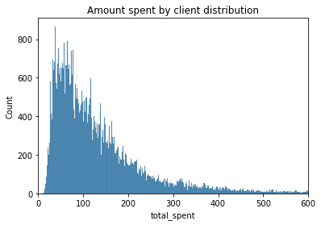

```python
plt.title('Amount spent by client distribution')
plt.xlim(right = 600)
sns.histplot(data = df['total_spent'])
```

By looking into the histogram, we can assume most of the clients do not spend much on the platform. They mostly spent between 1 and 400 BRL for all the time they have registered.

```python
#Fill empty values on dataframe
df['total_spent'].fillna(value = 0, inplace = True)
```

Last, reshape the number of transactions based on the time a client has entered the system, creating a column that measures average purchases/year:

```python
#get the dates between first purchase and last date in dataset
last_date = (df['first_purchase'].max() - df['first_purchase'].min())/np.timedelta64(1,'D')
dates_btwn = list(((df['first_purchase'].max() - df['first_purchase'])/np.timedelta64(1,'D'))/last_date)

#Create column to store #purchases * dates_between
df['normalized_transactions'] = df['transactions'] * dates_btwn
df['normalized_transactions'].describe()
```

```
count    96485.000000
mean         0.353013
std          0.290259
min          0.000000
25%          0.164398
50%          0.314123
75%          0.500727
max         16.338439
Name: normalized_transactions, dtype: float64
```

Then, we check the data same as for the totalamount feature:

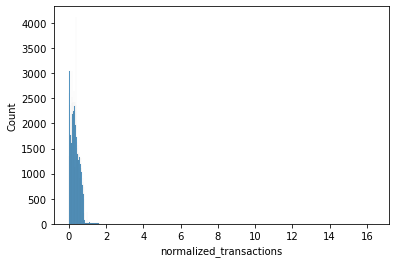

```python
sns.histplot(data = df['normalized_transactions'])
```

That means our data is full with outliers. We have to drop them, to build a more reliable model:

```python
df.rename(columns={'normalized_transactions': 'normalized_frequency'}, inplace = True)
df.drop(df[df['normalized_frequency'] > 1.18].index, inplace = True)
```

```python
df_new = df.drop(df[df['total_spent'] > 400].index)
```

## 3. KMeans clusterization

Next step is to build KMeans model, using the data fetched from mySQL:  
K-means clustering is a method of vector quantization, originally from signal processing, that aims to partition n observations into k clusters in which each observation belongs to the cluster with the nearest mean (cluster centers or cluster centroid), serving as a prototype of the cluster.  
K-means clustering minimizes within-cluster variances (squared Euclidean distances), but not regular Euclidean distances, which would be the more difficult Weber problem: the mean optimizes squared errors, whereas only the geometric median minimizes Euclidean distances.

```python
from sklearn.cluster import KMeans

#Define the feature(s) to be labeled
feature = df_new[['customer_id', 'total_spent', 'normalized_frequency']]

#feature = np.array(feature).reshape(-1,1)
# Keep track of results
track = {}
labels = {}

# Find the optimal K
for k in range(2, 10):
    model = KMeans(n_clusters= k, random_state = 1)
    model.fit(feature)
    track[k] = model.inertia_
    labels[k] = model.labels_
```

Use an Elbow Plot to verify the ideal number of clusters in the data.

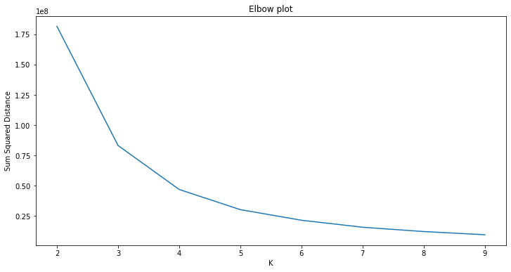

```python
#Plot results to find optimal k:
plt.figure(figsize=(12,6))
plt.title('Elbow plot')
plt.xlabel('K')
plt.ylabel('Sum Squared Distance')
plt.plot(track.keys(), track.values())
```

- Add the labels column to be updated at Database:

```python
df_new['labels'] = labels[5]
```

## 4. Conclusion

It is clear that beyond k = 5 the `Sum Squared Distance` starts to take a more plain decrease. Therefore, it is best to assume the optimal number of clusters is 5. Last we will use a scatterplot to see how the data is clustered:

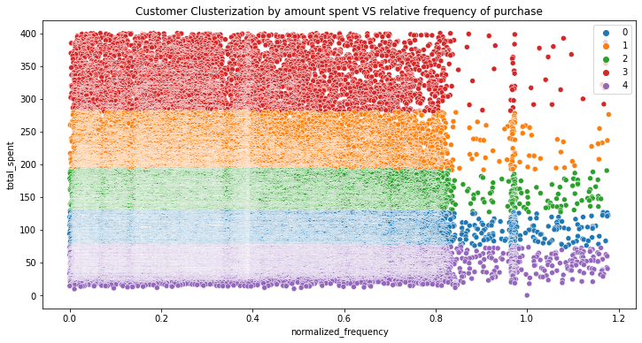

```python
plt.figure(figsize=(12,6))
plt.title('Customer Clusterization by amount spent VS relative frequency of purchase')
sns.scatterplot(x = df_new['normalized_frequency'], y = df_new['total_spent'], hue = labels[5], palette = 'tab10')
```

- It seems to be a clear threshold were the customer changes cluster for the amount spent on the platform, but not for the normalized frequency of transactions. Although KMeans does not provide a clear distinction of client importance in it's label name, we can easily rename them to clearly distinguish them.
- Lastly we can also input the labels back into the SQL database, following the same principle we did to extract the data:

```python
df_new['labels'] = df_new['labels'].rename({3: 'class A',
                                            1: 'class B',
                                            2: 'class C',
                                            0: 'class D',
                                            4: 'class E'})
```

```python
conector = connect(host='localhost',
                  user='root',
                  password='Musica10',
                  database='ecommerce_db')

cursor = conector.cursor()

####

Line2 =f'''
ALTER TABLE customers
ADD COLUMN labels CHAR(1);
'''
cursor.execute(Line2)
for lab in df_new['labels']:
    Line3 = f'''
    UPDATE customers
    SET labels = "{lab}"
    WHERE customer_id = "{df_new['customer_id']}"
    '''
    cursor.execute(Line3)
conector.commit()

####

cursor.close()
conector.close()
```

And now we have it! Using ML, we can continuously classify new customers and update the database.